# READ_ME

Aïssa Morin

2023-05-19

```r
library(kableExtra)
require(tidyverse)
require(here)
require(ggplot2)
require(readr)
```

## Data preparation

N.B: Copy of the original data from Yolan are in Chapter_2_Dryness… -> documents –> Donnees_Yolan –> Donnee_Yolan_05-2023–> ‘Data_Fat_analyses_Yolan’

Original dataset was modified and saved under ‘Data_Fat_analyses_raw’ in ‘Chapter2.Dryness. …’–> data –> ‘Data_Fat_analyses_raw’

Modifications (manual because color coded) on xlxs file –> column addition: ’collection_interval, values (i.e. Yolan color code)) :

- blue –> early : sample collected within 6 days,
- yellow –> intermediate : sample collected between 6 and 8 days (included ?),
- red –> late : sample collected after 8 days (should be exclude from analyses)

Save as a csv file for R processing

**Read data**

use function ‘read_fat_data_raw()’ to read csv file with raw fat data from Yolan

**Clean dataset**

Aim at cleaning, organising and only keep necessary info from fat raw data using the function ‘clean_raw_fat_data’

**Save cleaned dataset**

Aim at saving cleaned data for fat analyses ‘save_cleaned_data’

The function takes 2 arguments :

- *cleaned_data* : cleaned raw data for fat analyses (after using clean_raw_fat_data function)
- *filename* : the name we want the dataset to be saved under

The cleaned dataset is saved under ./output/clean_fat_data/

## Data Exploration

**Within samples variation**

Graphical representation of the spread/distribution of dry-mass values for each sample (Hip_B_…etc)

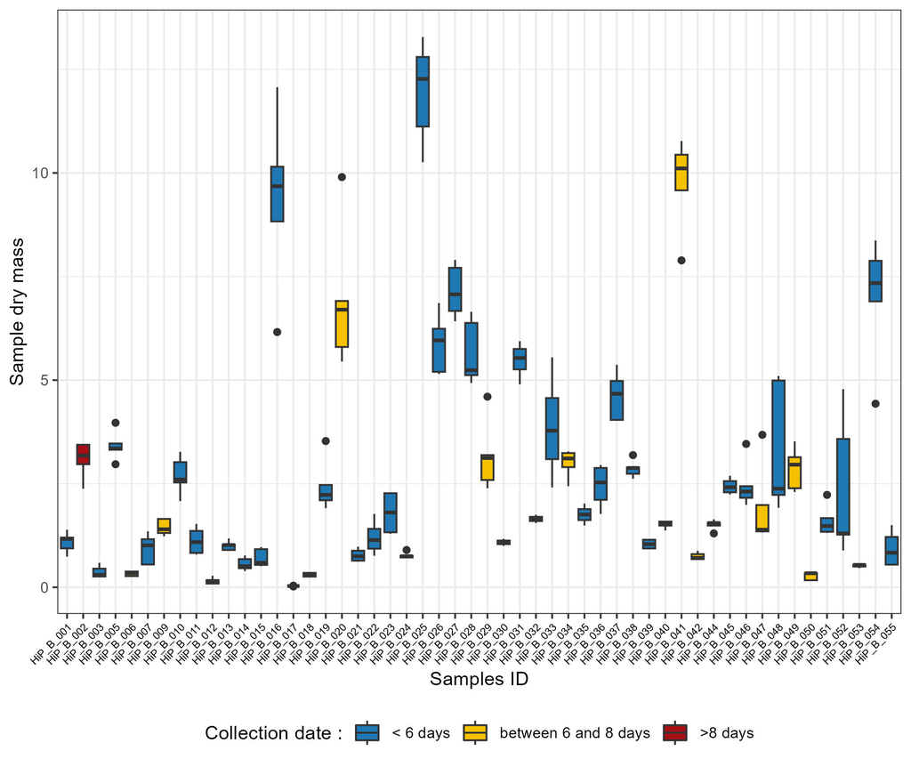

Table with coefficients of variation calculated per sample

| samples_ID | nb_sub_samples | mean_dry_mass | sd_dry_mass | CV_dry_mass |
| --- | --- | --- | --- | --- |
| HiP_B_001 | 5 | 1.0880000 | 0.2517340 | 0.2313731 |
| HiP_B_002 | 5 | 3.0840000 | 0.4411689 | 0.1430509 |
| HiP_B_003 | 5 | 0.3680000 | 0.1488959 | 0.4046085 |
| HiP_B_005 | 5 | 3.4160000 | 0.3613585 | 0.1057841 |
| HiP_B_006 | 5 | 0.3320000 | 0.0605805 | 0.1824715 |
| HiP_B_007 | 5 | 0.9220000 | 0.3646505 | 0.3954995 |
| HiP_B_009 | 5 | 1.4500000 | 0.1965960 | 0.1355835 |
| HiP_B_010 | 5 | 2.7000000 | 0.4611399 | 0.1707926 |
| HiP_B_011 | 5 | 1.1200000 | 0.3238827 | 0.2891810 |
| HiP_B_012 | 5 | 0.1520000 | 0.0825833 | 0.5433111 |
| HiP_B_013 | 5 | 1.0020000 | 0.1204990 | 0.1202584 |
| HiP_B_014 | 5 | 0.5620000 | 0.1580190 | 0.2811726 |
| HiP_B_015 | 5 | 0.7060000 | 0.2207487 | 0.3126752 |
| HiP_B_016 | 5 | 9.3780000 | 2.1557992 | 0.2298783 |
| HiP_B_017 | 5 | 0.0300000 | 0.0070711 | 0.2357023 |
| HiP_B_018 | 4 | 0.3050000 | 0.0591608 | 0.1939698 |
| HiP_B_019 | 5 | 2.4480000 | 0.6382163 | 0.2607093 |
| HiP_B_020 | 5 | 6.9520000 | 1.7563513 | 0.2526397 |
| HiP_B_021 | 4 | 0.7750000 | 0.1705872 | 0.2201125 |
| HiP_B_022 | 4 | 1.2025000 | 0.4361479 | 0.3627010 |
| HiP_B_023 | 4 | 1.7925000 | 0.5517472 | 0.3078088 |
| HiP_B_024 | 5 | 0.7700000 | 0.0748331 | 0.0971859 |
| HiP_B_025 | 5 | 11.9460000 | 1.2388220 | 0.1037018 |
| HiP_B_026 | 5 | 5.8820000 | 0.7231321 | 0.1229398 |
| HiP_B_027 | 5 | 7.1540000 | 0.6414281 | 0.0896601 |
| HiP_B_028 | 5 | 5.6640000 | 0.7904619 | 0.1395589 |
| HiP_B_029 | 5 | 3.1780000 | 0.8649104 | 0.2721556 |
| HiP_B_030 | 2 | 1.0850000 | 0.1202082 | 0.1107909 |
| HiP_B_031 | 4 | 5.4775000 | 0.4479862 | 0.0817866 |
| HiP_B_032 | 2 | 1.6500000 | 0.1414214 | 0.0857099 |
| HiP_B_033 | 4 | 3.8800000 | 1.3407709 | 0.3455595 |
| HiP_B_034 | 5 | 2.9940000 | 0.3433366 | 0.1146749 |
| HiP_B_035 | 2 | 1.7550000 | 0.3747666 | 0.2135422 |
| HiP_B_036 | 5 | 2.4480000 | 0.5047970 | 0.2062079 |
| HiP_B_037 | 5 | 4.6160000 | 0.5896864 | 0.1277483 |
| HiP_B_038 | 5 | 2.8640000 | 0.2133776 | 0.0745034 |
| HiP_B_039 | 4 | 1.0450000 | 0.1276715 | 0.1221736 |
| HiP_B_040 | 4 | 1.5200000 | 0.1042433 | 0.0685811 |
| HiP_B_041 | 5 | 9.7580000 | 1.1329475 | 0.1161045 |
| HiP_B_042 | 5 | 0.7480000 | 0.0898332 | 0.1200978 |
| HiP_B_044 | 5 | 1.5080000 | 0.1279453 | 0.0848444 |
| HiP_B_045 | 4 | 2.4400000 | 0.2047763 | 0.0839247 |
| HiP_B_046 | 5 | 2.4720000 | 0.5772954 | 0.2335337 |
| HiP_B_047 | 4 | 1.9450000 | 1.1573965 | 0.5950625 |
| HiP_B_048 | 5 | 3.3240000 | 1.5802626 | 0.4754099 |
| HiP_B_049 | 5 | 2.8620000 | 0.5144123 | 0.1797387 |
| HiP_B_050 | 5 | 0.2740000 | 0.1050238 | 0.3832986 |
| HiP_B_051 | 5 | 1.6060000 | 0.3767360 | 0.2345803 |
| HiP_B_052 | 5 | 2.3640000 | 1.7188165 | 0.7270797 |
| HiP_B_053 | 3 | 0.5166667 | 0.0493288 | 0.0954752 |
| HiP_B_054 | 5 | 6.9840000 | 1.5313817 | 0.2192700 |
| HiP_B_055 | 4 | 0.9275000 | 0.4681435 | 0.5047369 |

CV < 1 i.e. SD < mean –> relatively low variability ?